Importamos las librerías necesarias. Si hace falta, hay que instalarlas descomentando la línea necesaria.

```r
# install.packages("DBI")
# install.packages("RSQLite")

library(DBI)
library(RSQLite)
```

Escribimos la ubicación del archivo compas.db Utilizamos los drivers instalados de SQLite para poder pasar el archivo a un data.frame que puede ser manipulado por R.

```r
filename <- "compas.db"
sqlite.driver <- dbDriver("SQLite")
db <- dbConnect(sqlite.driver,
                dbname = filename)
```

El objeto db contiene las 7 tablas que pertenecen a compas. Para obtener un dataframe con alguna de las tablas, vasta con descomentar la linea que lee una tabla.

```r
# dbListTables(db)
# >>> "people"  "casearrest"  "charge"  "compas"  "jailhistory" "prisonhistory" "summary"

people <- dbReadTable(db,"people")
casearrest <- dbReadTable(db,"casearrest")
charge <- dbReadTable(db,"charge")
compas <- dbReadTable(db,"compas")
jailhistory <- dbReadTable(db,"jailhistory")
prisonhistory <- dbReadTable(db,"prisonhistory")
summary <- dbReadTable(db,"summary")
```

Vemos en el siguiente diagrama que todas las tablas poseen una única llave primaria que es el id mientras que posee una única llave foránea, el id de una persona. Mientras que la tabla people representa a una de estas, siendo su única llave primaria su id.

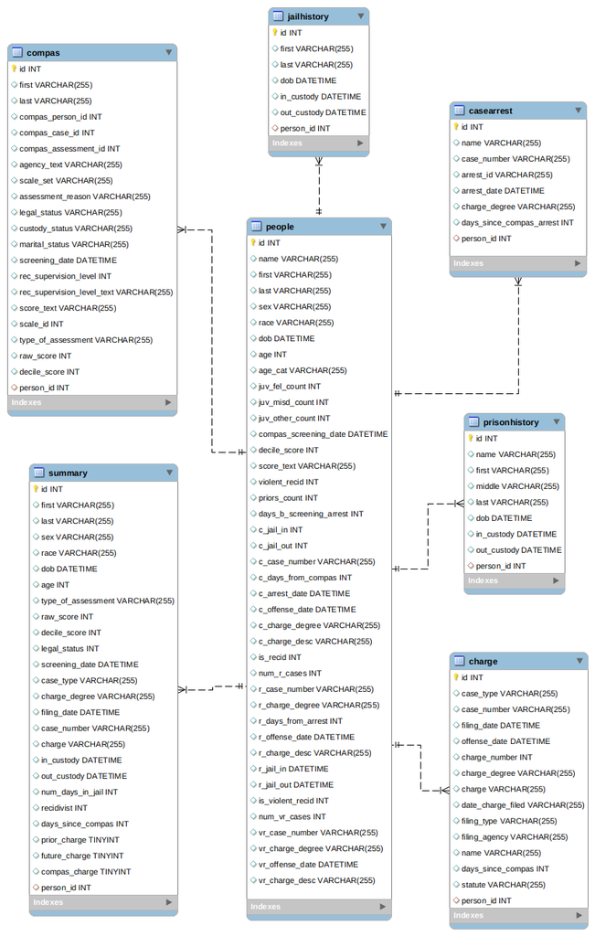

Diagrama E-R

```r
str(people)
```

```
## 'data.frame':    11757 obs. of  41 variables:
##  $ id                     : int  1 2 3 4 5 6 7 8 9 10 ...
##  $ name                   : chr  "miguel hernandez" "michael ryan" "kevon dixon" "ed philo" ...
##  $ first                  : chr  "miguel" "michael" "kevon" "ed" ...
##  $ last                   : chr  "hernandez" "ryan" "dixon" "philo" ...
##  $ sex                    : chr  "Male" "Male" "Male" "Male" ...
##  $ race                   : chr  "Other" "Caucasian" "African-American" "African-American" ...
##  $ dob                    : chr  "1947-04-18 00:00:00.000000" "1985-02-06 00:00:00.000000" "1982-01-22 00:00:00.000000" "1991-05-14 00:00:00.000000" ...
##  $ age                    : int  69 31 34 24 23 43 44 41 43 39 ...
##  $ age_cat                : chr  "Greater than 45" "25 - 45" "25 - 45" "Less than 25" ...
##  $ juv_fel_count          : int  0 0 0 0 0 0 0 0 0 0 ...
##  $ juv_misd_count         : int  0 0 0 0 1 0 0 0 0 0 ...
##  $ juv_other_count        : int  0 0 0 1 0 0 0 0 0 0 ...
##  $ compas_screening_date  : chr  "2013-08-14 00:00:00.000000" "2014-12-31 00:00:00.000000" "2013-01-27 00:00:00.000000" "2013-04-14 00:00:00.000000" ...
##  $ decile_score           : int  1 5 3 4 8 1 1 6 4 1 ...
```

[output cut: 27 more lines]

**people** -> Una entidad persona. Es la tabla principal que almacena todos los datos de un condenado, tal como su sexo, edad, raza, etc… y con la que se trabajará en mayor medida.

```r
str(casearrest)
```

```
## 'data.frame':    128183 obs. of  8 variables:
##  $ id                      : int  1 2 3 4 5 6 7 8 9 10 ...
##  $ name                    : chr  "aajah herrington" "aajah herrington" "aajah herrington" "aaliyah lovo" ...
##  $ case_number             : chr  "13005832CF10A" "13005832CF10A" "14007863MM10A" "13015312CF10A" ...
##  $ arrest_id               : chr  "3026755" "3026756" "3144392" "3084831" ...
##  $ arrest_date             : chr  "2013-04-23 00:00:00.000000" "2013-04-23 00:00:00.000000" "2014-05-13 00:00:00.000000" "2013-11-03 00:00:00.000000" ...
##  $ charge_degree           : chr  "(F3)" "(M2)" "(M1)" "(F2)" ...
##  $ days_since_compas_arrest: int  1 1 -384 1 1 272 261 128 -70 272 ...
##  $ person_id               : int  533 533 533 900 900 4474 4474 4474 4474 4474 ...
```

**casearrest** -> EL caso de arresto, se repiten personas que se diferencian por días de arresto y grado del cargo principalmente.

```r
str(charge)
```

```
## 'data.frame':    148086 obs. of  15 variables:
##  $ id               : int  1 2 3 4 5 6 7 8 9 10 ...
##  $ case_type        : chr  "" "" "" "" ...
##  $ case_number      : chr  "13005832CF10A" "13005832CF10A" "14042370TC10A" "14007863MM10A" ...
##  $ filing_date      : chr  "1800-01-01 00:00:00.000000" "1800-01-01 00:00:00.000000" "1800-01-01 00:00:00.000000" "1800-01-01 00:00:00.000000" ...
##  $ offense_date     : chr  "2013-04-23 00:00:00.000000" "2013-04-23 00:00:00.000000" "2014-11-11 00:00:00.000000" "2014-05-13 00:00:00.000000" ...
##  $ charge_number    : int  1 2 1 1 1 2 1 2 3 4 ...
##  $ charge_degree    : chr  "(F3)" "(M2)" "(M2)" "(M1)" ...
##  $ charge           : chr  "Driving While License Revoked" "Petit Theft" "Driving License Suspended" "Extradition/Defendants" ...
##  $ date_charge_filed: chr  "2013-04-23 00:00:00" "2013-04-23 00:00:00" "2014-11-11 00:00:00" "2014-05-13 00:00:00" ...
##  $ filing_type      : chr  "No Information/ Transfer to Misdemeanor" "Transfer to County Court" NA "Fugitive" ...
##  $ filing_agency    : chr  "Fort Lauderdale PD" "Fort Lauderdale PD" "Fort Lauderdale PD" "Fort Lauderdale PD" ...
##  $ name             : chr  "aajah herrington" "aajah herrington" "aajah herrington" "aajah herrington" ...
##  $ days_since_compas: int  1 1 -566 -384 661 661 417 417 417 417 ...
##  $ statute          : chr  "322.34(5)" "812.014(3)(a)" "322.34(2)" "941.02" ...
##  $ person_id        : int  533 533 533 533 533 533 533 533 533 533 ...
```

**charge** -> Especifica el cargo que se le acusa a una persona y otros datos.

```r
str(compas)
```

```
## 'data.frame':    37578 obs. of  21 variables:
##  $ id                        : int  1 2 3 4 5 6 7 8 9 10 ...
##  $ first                     : chr  "miguel" "miguel" "miguel" "michael" ...
##  $ last                      : chr  "hernandez" "hernandez" "hernandez" "ryan" ...
##  $ compas_person_id          : int  56418 56418 56418 68603 68603 68603 51601 51601 51601 38864 ...
##  $ compas_case_id            : int  58393 58393 58393 72042 72042 72042 52796 52796 52796 55421 ...
##  $ compas_assessment_id      : int  64352 64352 64352 79669 79669 79669 58102 58102 58102 61042 ...
##  $ agency_text               : chr  "PRETRIAL" "PRETRIAL" "PRETRIAL" "PRETRIAL" ...
##  $ scale_set                 : chr  "Risk and Prescreen" "Risk and Prescreen" "Risk and Prescreen" "Risk and Prescreen" ...
##  $ assessment_reason         : chr  "Intake" "Intake" "Intake" "Intake" ...
##  $ legal_status              : chr  "Pretrial" "Pretrial" "Pretrial" "Pretrial" ...
##  $ custody_status            : chr  "Jail Inmate" "Jail Inmate" "Jail Inmate" "Jail Inmate" ...
##  $ marital_status            : chr  "Single" "Single" "Single" "Single" ...
##  $ screening_date            : chr  "2013-08-14 00:00:00.000000" "2013-08-14 00:00:00.000000" "2013-08-14 00:00:00.000000" "2014-12-31 00:00:00.000000" ...
##  $ rec_supervision_level     : int  1 1 1 1 1 1 1 1 1 1 ...
##  $ rec_supervision_level_text: chr  "Low" "Low" "Low" "Low" ...
##  $ score_text                : chr  "Low" "Low" "Low" "Low" ...
##  $ scale_id                  : int  7 8 18 7 8 18 7 8 18 7 ...
##  $ type_of_assessment        : chr  "Risk of Violence" "Risk of Recidivism" "Risk of Failure to Appear" "Risk of Violence" ...
##  $ raw_score                 : num  -4.31 -2.78 13 -2.75 -0.34 16 -3.07 -0.76 25 -2.26 ...
##  $ decile_score              : int  1 1 1 2 5 2 1 3 6 3 ...
##  $ person_id                 : int  1 1 1 2 2 2 3 3 3 4 ...
```

**compas** -> Es la puntuación compas que se le asigna a una persona. Generalmente se presentan las tres puntuaciones para cada individuo (Riesgo de reincidencia con y sin violencia y riesgo de no acudir a la citación).

```r
str(jailhistory)
```

```
## 'data.frame':    22111 obs. of  7 variables:
##  $ id         : int  1 2 3 4 5 6 7 8 9 10 ...
##  $ first      : chr  "victor" "pierre" "diana" "thomas" ...
##  $ last       : chr  "lozada" "merilus" "loubeau" "carter" ...
##  $ dob        : chr  "1951-05-12 00:00:00.000000" "1993-03-31 00:00:00.000000" "1993-10-01 00:00:00.000000" "1961-01-17 00:00:00.000000" ...
##  $ in_custody : chr  "2013-08-05 12:41:27.000000" "2014-11-14 12:27:25.000000" "2014-05-01 09:46:32.000000" "2013-05-25 05:28:09.000000" ...
##  $ out_custody: chr  "2013-08-13 02:27:19.000000" "2014-11-16 03:01:50.000000" "2014-05-02 09:39:12.000000" "2013-05-26 08:34:54.000000" ...
##  $ person_id  : int  880 2799 486 7902 3369 7278 2262 4327 7693 10825 ...
```

**jailhistory** -> Esta tabla guarda el historial de arresto en custodia????? de cada persona. Fecha y hora de cuando sale y entra.

```r
str(prisonhistory)
```

```
## 'data.frame':    4945 obs. of  9 variables:
##  $ id         : int  1 2 3 4 5 6 7 8 9 10 ...
##  $ name       : chr  NA NA NA NA ...
##  $ first      : chr  "bilal" "eduardo" "brenley" "michael" ...
##  $ middle     : chr  NA NA NA NA ...
##  $ last       : chr  "williams" "cisneros" "johnson" "stenquist" ...
##  $ dob        : chr  "1955-05-12 00:00:00.000000" "1979-08-23 00:00:00.000000" "1962-08-24 00:00:00.000000" "1980-12-30 00:00:00.000000" ...
##  $ in_custody : chr  "1986-03-13 00:00:00.000000" "2015-02-24 00:00:00.000000" "2008-03-24 00:00:00.000000" "2015-07-02 00:00:00.000000" ...
##  $ out_custody: chr  "1987-02-19 00:00:00.000000" "2020-01-01 00:00:00.000000" "2009-01-01 00:00:00.000000" "2015-07-08 00:00:00.000000" ...
##  $ person_id  : int  4813 7889 9400 11598 320 8802 2517 2327 10471 8344 ...
```

**prisonhistory** -> Esta tabla guarda el historial de arresto con prisión?????? de cada persona. Fecha y hora de cuando sale y entra.

```r
str(summary)
```

```
## 'data.frame':    0 obs. of  26 variables:
##  $ id                : int
##  $ first             : chr
##  $ last              : chr
##  $ sex               : chr
##  $ race              : chr
##  $ dob               : num
##  $ age               : int
##  $ type_of_assessment: chr
##  $ raw_score         : int
##  $ decile_score      : int
##  $ legal_status      : int
##  $ screening_date    : num
##  $ case_type         : chr
##  $ charge_degree     : chr
##  $ filing_date       : num
##  $ case_number       : chr
##  $ charge            : chr
##  $ in_custody        : num
##  $ out_custody       : num
##  $ num_days_in_jail  : int
##  $ recidivist        : int
##  $ days_since_compas : int
##  $ prior_charge      : num
##  $ future_charge     : num
##  $ compas_charge     : num
##  $ person_id         : int
```

**summary** -> Ni idea :(